# systemPipeShiny

Author: Le Zhang, Daniela Cassol, Ponmathi Ramasamy, Jianhai Zhang, Gordon Mosher and Thomas Girke

Last update: 30 September, 2020

[figure not shown]

# 1 Introduction

**systemPipeShiny** (SPS) extends the widely used [systemPipeR](https://bioconductor.org/packages/systemPipeR/) (SPR) workflow environment with a versatile graphical user interface provided by a [Shiny App](https://shiny.rstudio.com). This allows non-R users, such as experimentalists, to run many systemPipeR’s workflow designs, control, and visualization functionalities interactively without requiring knowledge of R. Most importantly, `SPS` has been designed as a general purpose framework for interacting with other R packages in an intuitive manner. Like most Shiny Apps, SPS can be used on both local computers as well as centralized server-based deployments that can be accessed remotely as a public web service for using SPR’s functionalities with community and/or private data. The framework can integrate many core packages from the R/Bioconductor ecosystem. Examples of SPS’ current functionalities include: (a) interactive creation of experimental designs and metadata using an easy to use tabular editor or file uploader; (b) visualization of workflow topologies combined with auto-generation of R Markdown preview for interactively designed workflows; (c) access to a wide range of data processing routines; (d) and an extendable set of visualization functionalities. Complex visual results can be managed on a ‘Canvas Workbench’ allowing users to organize and to compare plots in an efficient manner combined with a session snapshot feature to continue work at a later time. The present suite of pre-configured visualization examples include different methods to plot a count table: PCA, t-SNE and plots of other clustering methods; volcano plots, data mining plots including heatmaps, and more. The modular design of SPR makes it easy to design custom functions without any knowledge of Shiny, as well as extending the environment in the future with contributions from the community.

Dani: My opinion here is that if we mentioned some plot here, we should provide the plots on the visualization tabs since we already have these plots organized. ThG: so why are they not shown by default for demo purposes?

An example web instance for testing `SPS` online is available [here](https://tgirke.shinyapps.io/systemPipeShiny/). At the time of writing, there are five interactive tutorials embedded in this instance that users can access from the upper-right corner. Each tutorial introduces major functionalities of SPS.

# 2 Installation

The `systemPipeShiny` package can be installed from a user’s R console as follows.

```r
if (!requireNamespace("BiocManager", quietly = TRUE)) install.packages("BiocManager")
BiocManager::install("systemPipeShiny")
```

If the user’s OS is Linux then one may need to install the following dependencies. The following example applies to Ubuntu.

```bash
sudo apt-get install libv8-dev
sudo apt-get install libssl-dev
sudo apt-get install libcurl4-openssl-dev
```

*libcurl4-openssl-dev* may not be required for Ubuntu > 18.04.

On other Linux distributions, the install commands may be slightly different.

# 3 Main functionalities

Currently, `SPS` includes two main functional categories: (1) a workbench for designing and configuring data analysis workflows (WF), and (2) a data visualization (VS) toolbox (*Fig 1*). The WF module allows to write and to modify configuration files required for running workflows in `systemPipeR`. The VS module provides a rich set of plotting tools to visualize the results of individual steps in `systemPipeR` workflow. The latter includes a Canvas functionality that allows to arrange many plots in one page, save their them and revisit the saved plots at a later time.

[figure not shown]

**Figure 1.** Design of `systemPipeShiny.` The framework provides an interactive web interface for workflow management and data visualization.

Within the functional categories, `SPS` functions are modularized in sub-components, here referred to as **SPS tabs** that are similar to menu tabs in other GUI applications that organize related and inter-connected functionalies into groups. On the backend, **SPS tabs** are based on [Shiny modules](https://shiny.rstudio.com/articles/modules.html), that are stored in separate files. This modular structure is highly extensible and greatly simplifies the design of new `SPS` tabs by both users and/or developers. Details about extending existing tabs and designing new ones are provided in an advanced user section.

# 4 Example workflow with toy RNA-Seq data

The following sections illustrate the main functionalities of `SPS` using an analysis workflow for RNA-Seq data as an example.

## 4.1 Load package

Load the `systemPipeShiny` package in your R session.

```r
library(systemPipeShiny)
```

## 4.2 Initialize `SPS` project

Before launching the `SPS` application, a project environment needs to be created with the following command.

```r
spsInit()
```

For this toy example, the project directory structure is written to a temporary directory on a user’s system. For a real project, it should be written to a defined and user controlled location on a system rather than a temporary directory.

```r
sps_tmp_dir <- tempdir()
spsInit(app_path = sps_tmp_dir, change_wd = FALSE, project_name = "SPSProject")
```

```
## [SPS-INFO] 2020-09-30 12:11:37 Start to create a new SPS project
```

```
## [SPS-INFO] 2020-09-30 12:11:37 Create project under /tmp/RtmpMbDPj8/SPSProject
```

```
## [SPS-INFO] 2020-09-30 12:11:37 Now copy files
```

```
## [SPS-INFO] 2020-09-30 12:11:37 Create SPS database
```

```
## [SPS-INFO] 2020-09-30 12:11:37 Created SPS database method container
```

```
## [SPS-INFO] 2020-09-30 12:11:38 Creating SPS db...
```

```
## [SPS-DANGER] 2020-09-30 12:11:38 Db created at '/tmp/RtmpMbDPj8/SPSProject/config/sps.db'. DO NOT share this file with others
## [SPS-INFO] 2020-09-30 12:11:38 Key md5 99136050c3ed87d49fa85939cfa89c13
## [SPS-INFO] 2020-09-30 12:11:38 SPS project setup done!
```

[output not shown]

[output not shown]

[output not shown]

[output not shown]

[output not shown]

[output not shown]

[output not shown]

```r
sps_dir <- file.path(sps_tmp_dir, "SPSProject")
```

### 4.2.1 SPS project structure

The file and directory structure of an SPS project is organized as follows.

```
SPS_xx/
├── server.R               |
├── global.R               | Most important server, UI and global files, unless special needs, `global.R` is the only file you need to edit manually
├── ui.R                   |
├── deploy.R               | Deploy helper file
├── config                 | Important app config files. Do not edit them if you don't know
│   ├── sps.db             | SPS database
│   ├── sps_options.yaml   | SPS default option list
│   └── tabs.csv           | SPS tab information
├── data                   | App example data files
│   ├── xx.csv
├── R                      | All SPS additional tab files and helper R function files
│   ├── tab_xx.R
├── README.md
├── results                | Not in use for this current version, you can store some data been generated from the app
│   └── README.md
└── www                    | Internet resources
    ├── about              | About tab information
    │   └── xx.md
    ├── css                | CSS files
    │   └── sps.css
    ├── img                | App image resources
    │   └── xx.png
    ├── js                 | Javascripts
    │   └── xx.js
    ├── loading_themes     | Loading screen files
    │   └── xx.html
    └── plot_list          | Image files for plot gallery
        └── plot_xx.jpg
```

## 4.3 Launch `SPS`

By default, the working directory will be set inside the project folder automatically. To launch the `SPS` Shiny application, one only needs to execute the following command.

```r
shiny::runApp()
```

After the SPS app has been launched, clicking the “Continue to app” button on the welcome screen will open the main dashboard (Fig.2).

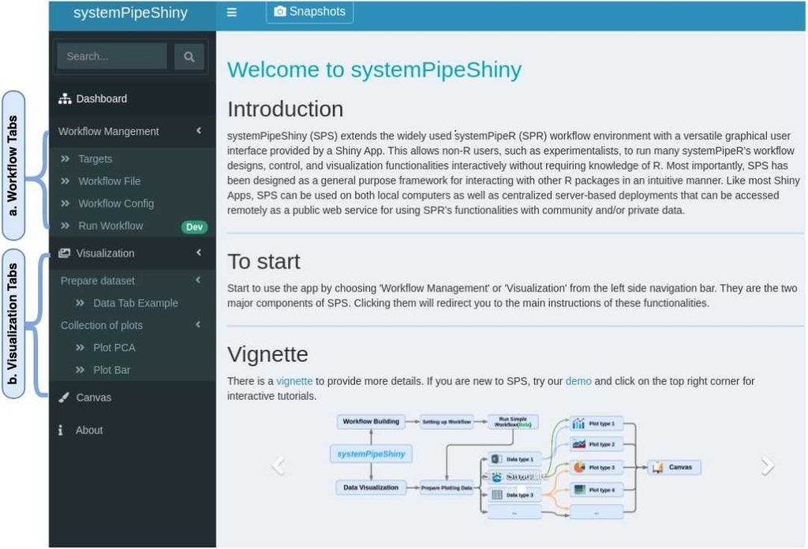

[figure not shown]

**Figure 2:** Snapshot of SPS’ UI.

ThG: note don’t center the legend of figures, and only the Figure xyz part should be in bold. The actual legend text is in non-bold.

Alternatively, when using RStudio one can click the `Run App` button in the top right corner.

In addition, in Rstudio the *global.R* file will be automatically opened when the `SPS` project is created. Custom changes can be made inside this file before the app launches. The advanced section explains how to create custom tabs.

Dani:I think this advanced information could be confusing in this stage of the documentation (discussing and showing details about the global.R file), so I believe we can add this to the advanced features section and just to link here. ThG: yes, just show some demo tabs and move the customization stuff to the advanced section.

## 4.4 Workflow management

The current version of `SPS` allows to create and/or check the format of these files. The execution of SPR workflows via SPS will be supported in the next release.

### 4.4.1 Prepare a target file

The targets file defines all input file paths and other sample information of analysis workflows. To better undertand the structure of this file, one can consult the [“Structure of targets file”](https://systempipe.org/docs/systemPipeR/#structure-of-targets-file) section in the SPR vignette. Essentially, this is the tabular file representation of the `colData` slot in an `SummarizedExperiment` object which stores sample IDs and other meta information.

The targets file describe all input samples for the analysis workflow, defining all the input file path information, sample name and comparisons, and any additional metadata associated with the sample. More details can be found on [“Structure of targets file”](https://systempipe.org/docs/systemPipeR/#structure-of-targets-file) section in `systemPipeR` vignette.

Dani: Should we load the targets file here to show an example on the vignette?

The following step-by-step instructions explain how to create and/or modify targets files using RNA-Seq as an example (Fig.3 A):

1. Choose “Targets” from navigation bar.
2. Select either “Example PE” or “Example SE”" for using a pair-end/single-end target file, then choose “confirm” on the pop-up. You will see the example is loaded like Figure 3A.
3. You can edit, right click to add/remove rows/columns (The first row is treated as column names).
4. SPR target file requires a header and you can edit it here. Headers should start with “#”.
5. The left section can help you to check sample statistics and file existence. Choose any column you want from the dropdown to check and watch the statistics bar change in this section;
6. Clicking on “Add to task” can help you to check if your target file has any formatting problem. You should see a green success pop-up if everything is right;
7. Now your target file is ready and you can click “save” to download it and later use in a SPR project.
8. Click on the “-” button on the “Workflow Progress”, you should see the “Targets file” becomes green.

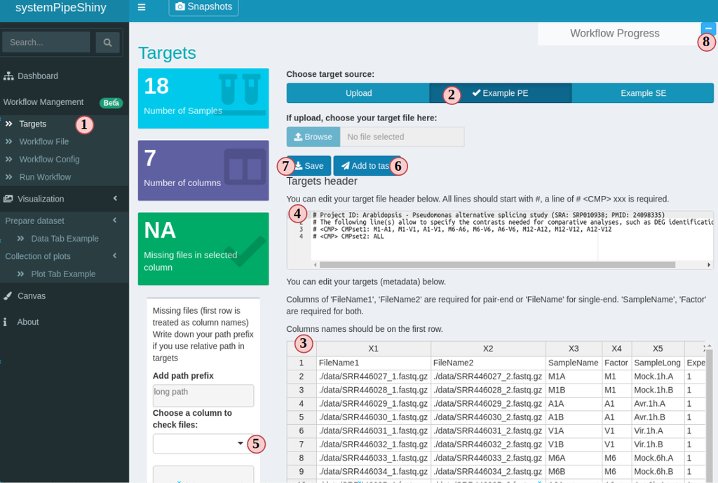

**Figure 3. A. Workflow Management - Targets File**

### 4.4.2 Prepare a workflow file

In SPR, workflows are defined in Rmarkdown files, you can read details and obtain them [here](https://systempipe.org/pages/pipelines_area/).

Now let us follow the order below to see how SPS helps you to prepare a workflow file for a RNAseq project (Fig.3 B):

1. Choose “Workflow File” from navigation bar;
2. Choose “Example Rmd” to load an RNAseq workflow;
3. You can see the workflow steps are displayed like a tree structure;
4. Check all steps in the workflow that you want to include. You can skip (leave blank) some steps but it may cause the workflow to fail. Read more SPR instructions before do so.
5. Clicking on the “Plot steps” will show a flow chart of what the step execution orders will be when you run the workflow in SPR.
6. Clicking “Report preview” generates a preview of what the final report will look like for current RNAseq workflow, but in the preview, no code is evaluated.
7. If you are satisfied with your workflow file, click “Add to task” to update the workflow preparation progress just like it is for “targets file”.
8. Now choose “Save New Rmd” to save this new workflow file to later be used a SPR RNAseq project running.

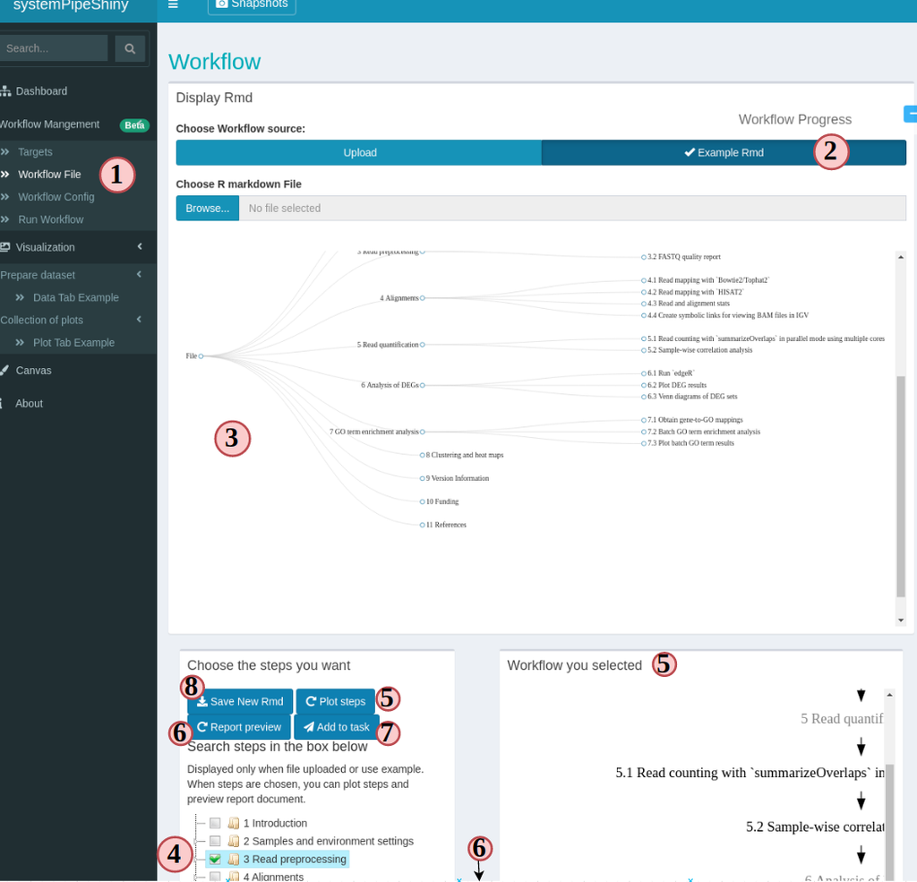

**Figure 3. B. Workflow Management - Workflow File**

### 4.4.3 Prepare a configuration file

In SPR, the config file *SPRconfig.yaml* is required to define information like *project path*, *targets file path* and more. Normally, this file is generated automatically when one starts a SPR project, but if any modification is made, one needs to update this config file. For example, like we are now using SPS to prepare targets file and workflow file and when we download these new files, file names and locations may be changed. In this case, we can update the config file in SPS (Fig.3 C):

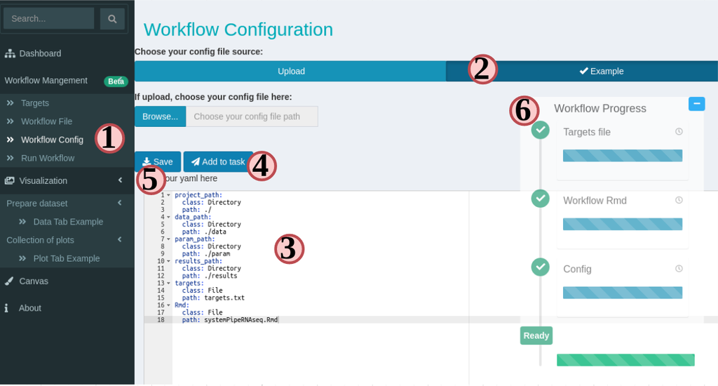

**Figure 3. C. Workflow Management - Config File**

### 4.4.4 Finish workflow management

If you have followed this instruction so far, the three most important workflow files have been created. You can copy them over to your SPR RNAseq project root and start to generate results.

## 4.5 Visualize workflow results

In the previous step that we have prepared files for running a SPR RNAseq workflow. Now assume that the workflow has been successfully run and we have obtained some results. In this part, we will use an example **count table** (RPKM normalized) to demonstrate how to use the VS components.

VS tabs in SPS are sub-defined into two small groups, *data tabs* and *plot tabs*. A data tab is where you prepare, filter and preprocess data. A plot tab is where the actual plots are generated. A plot tab requires at least one dataset from a data tab. Therefore, we need to first prepare data in a data tab, depending on the preprocess method we choose, we will be given different plot options (going to different plot tabs).

In this part, we will first load the raw count table and preprocess it in “Data Tab Example”, generate some plots in “Plot Tab Example”, and finally compare plots in the “Canvas” tab.

### 4.5.1 Load raw count data

Follow instructions in Figure 4A:

1. Select “Data Tab Example” tab from the left;
2. Click “Start with this tab”, it will be hidden after package requirement check has passed in the background. So it is not displayed in the figure.
3. Let us load an example RPKM read count table. If you upload your own table, the first column must be “Genes” and the rest of columns are treated as samples and they must be numeric values only.
4. You can click on box below each column name to filter data.
5. You can export your filtered data into clipboard, csv files, Excel …
6. After the data filtration, we can start to preprocess data. Here are two methods you can choose from the left dropdown menu: “Do Nothing” does not change the filtered data, and “PCA” calculates PCs based on samples. Let us just try “Do Nothing”;
7. When the data is preprocessed, plot options will be displayed in the below. You need to scroll down a little to see. “Do Nothing” will give you the option for a bar plot. Click on the plot image will redirect you to the corresponding tab.

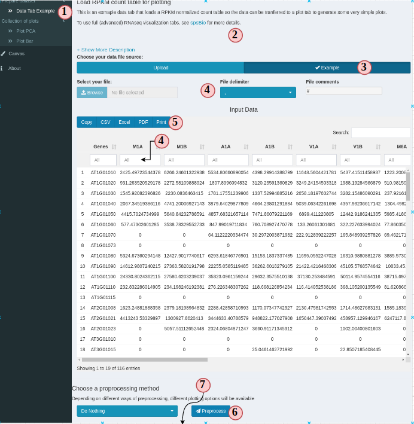

**Figure 4 A. VS - data tab**

### 4.5.2 Create a plot

Follow instructions in Figure 4B:

1. Skip this step if you jumped directly from the “Data Tab Example”, otherwise select “Plot Bar” to start;
2. Click “Start/Reload”, this button will validate if you have the required data set. If yes, you will see plot options and other UI.
3. Click on “Render/Snapshot plot” to create the first plot. In SPS, the first time clicking on “Render” button creates a preview of the plot. From the second time and on, clicking on this button will take a *“snapshot”* of the plot. In SPS a snapshot is plot frozen with particular set of input data and plot options. It is isolated from the original plot tab and you cannot modify it anymore. It is similar to a screenshot but you can still interact within the plot. You will have a better understanding when we reach the *Canvas* section.
4. Now you can interact with plot. Try to hover your mouse and move around the plot. There are many interactive components on the plot. Read more of what you can interact with a Plotly plot.
5. There is a tiny triangular icon on the right bottom corner of the plot where you can drag it to resize the plot to at most your window width and unlimited height;
6. A panel of plot selection tools including a screenshot button is on the top right;
7. Let us take a snapshot by clicking “Render”. You should see a blue message pop up from the right bottom of your screen.
8. You can change the plot title by changing the text. This example plot tab only provides very simple plot controls. Change the text and watch how the plot title change.
9. Change a title and click “Render” again to take a second snapshot.

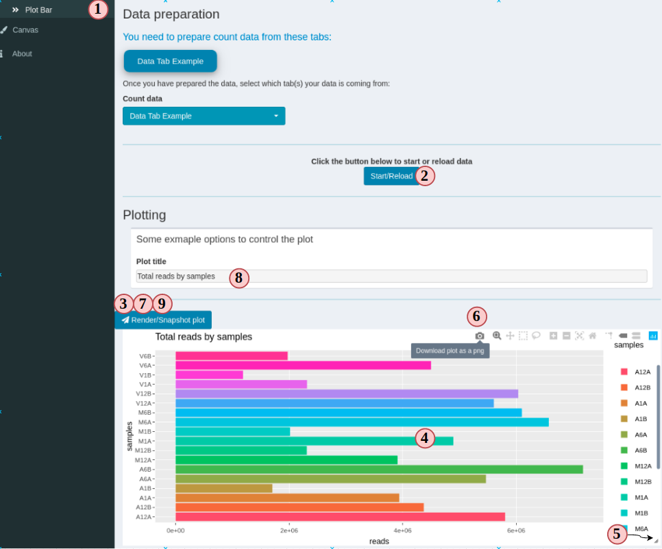

**Figure 4 B. VS - plot tab**

## 4.6 Snap shots and Canvas

### 4.6.1 Canvas

SPS Canvas is a place to display snapshots. Snap shots can come from different plot tabs, or the same plot tab with different plot options. Here you can combine plots together to a big scientific figure and compare plots with different plotting options side by side.

If you have followed the instructions so far, you should have at least two snapshots and we can start to use Canvas.

1. Select “Canvas” tab;
2. You will see your snapshots in “Current snapshots” box. If you do not want to see any of them, drag it to the right side so it will not be rendered on Canvas.
3. Click “Refresh Canvas” to render the Canvas for a quick glimpse;
4. You can change some Canvas settings on top;
5. In the “bar plot” section, we took two snapshots, one with original plot title and one with custom title. If you made the change, you can see it is reflected on Canvas. Move your mouse on the plots, you can see they are still interactive. Then, when you move the mouse near the top of a plot, a title section will show up and you can drag it to reposition your plot.
6. Similar to a plot tab, you can resize any plot on Canvas by dragging the bottom right corner of a plot.

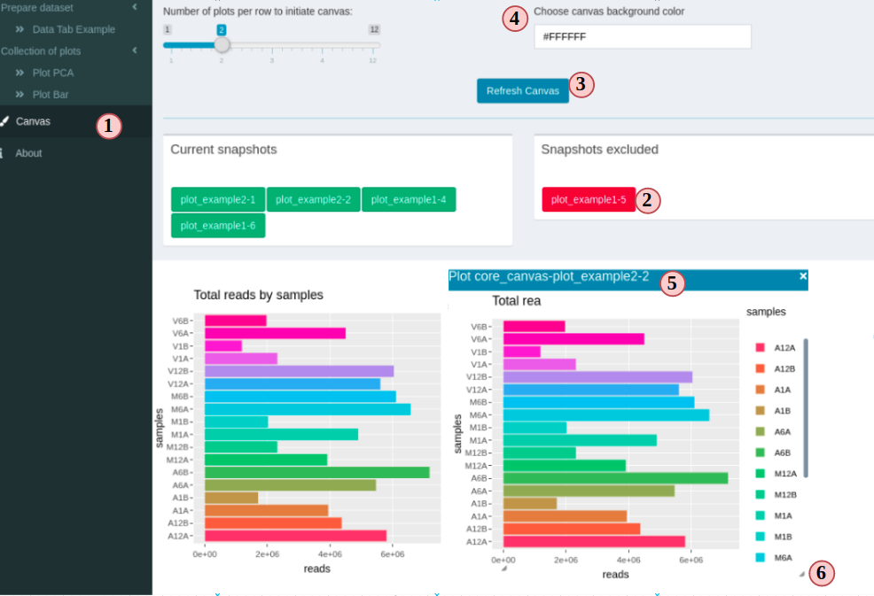

**Figure 5 A. Canvas**

Now go back to Load raw count data section and select “PCA” option in step 6 to reprocess and then go to PCA plot tab and repeat instructions in Create a plot to create and snapshot a few PCA plots. The PCA plot tab has an additional plot point size control UI. You can try to take snapshots with different point size. Finally come back to canvas and render all snapshots. You should then be able to see how point size on plots are different in different snapshots. Now you can have a better understanding of the SPS snapshot-Cnavas feature.

### 4.6.2 Snapshot management

Taking too many snapshots will slow down the app. A good solution is to manage them through the snapshot manage menu. You can access it by clicking the button “Snapshots” with a camera icon on the very top of SPS dashboard banner. It will open up a big menu screen (Fig. 5B).

1. The left side displays all current snapshots. The label means the plot tab ID of which plot tab it comes from and the number after the dash means it is the Nth snapshot coming from that particular plot tab;
2. If you want to delete any snapshot, drag it to the right;
3. Click on “DESTROY” will permanently delete selected snapshots and cannot be recovered.
4. Download your current snapshots to a compressed file.
5. You can upload saved snapshot file and continue to work on it later.

Due to internet security reasons, snapshot files are encrypted. Each SPS project has an unique key pair. Therefore, it is not possible to run a snapshot file in a different SPS project.

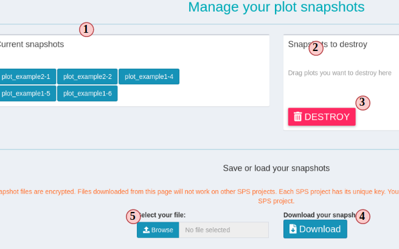

**Figure 5 B. snapshot management**

# 5 Advanced features

## 5.1 SPS plugins

We have created many more plots options and they are distributed as “SPS plugins”. A SPS plugin is a collection of SPS tabs that become small R packages. You need to install the plugin like you do with normal R packages by `install.packages`, `BiocManager::install` or `remotes::install_github()`. The plugins(packages) come with SPS tabs, data, and other helper functions. Using `spsAddPlugin()` function, you are able to load them into SPS framework.

Using `spsAddPlugin()` without any argument will list all available plugins and instructions to install them.

```r
spsAddPlugin()
```

```
## [SPS-INFO] 2020-09-30 12:11:38 Current SPS has following plugins
```

[output not shown]

```
## spsBio               Biological plots
## BiocManager::install("systemPipeR/spsBio")
```

To load a specific plugin:

```r
spsAddPlugin(plugin = "PLUGIN_NAME", app_path = "PATH_OF_SPS")
```

At this stage, there is only one plugin, the *spsBio*: plots for biological data visualization. It is **under testing and please expect unstableness**. Under your project directory:

```r
remotes::install_github("systemPipeR/spsBio")
spsAddPlugin(plugin = "spsBio")
```

Inside your SPS project root, in the *global.R* file, specify that you want to load the plugin to app and start the app like normal:

```r
sps_app <- sps(vstabs = c("data_example", "plot_example1", "plot_example2"),
    plugin = "spsBio", server_expr = {
        msg("Custom expression runs -- Hello World", "GREETING",
            "green")
    })
```

## 5.2 Configuration

### 5.2.1 App options

App options in SPS are controlled by “SPS options”. These options can change app appearance, debugging level, server server behaviors, *etc*. The valid options can be found and change on the `global.R` file. They are similar to *Shiny* options, but unlike *shiny* options are single values, SPS options are passed using the `Option(sps = list(...))` function in `global.R` as a group. To view all options and their default, valid values(’*’ means any value is okay):

```r
viewSpsDefaults(app_path = sps_dir)
```

```
## mode: list(default = "local", other = "server")
##  loading_screen: list(default = TRUE, other = FALSE)
##  loading_theme: list(default = "vhelix", other = "*")
##  use_crayon: list(default = TRUE, other = FALSE)
##  verbose: list(default = FALSE, other = TRUE)
##  admin_page: list(default = FALSE, other = TRUE)
##  admin_url: list(default = "admin", other = "*")
##  warning_toast: list(default = TRUE, other = FALSE)
```

To view a single option value, use `spsOption(opt = "OPTION_NAME")`; to overwrite a single option, use `spsOption(opt = "OPTION_NAME", value = "NEW_VALUE")`.

Note: Do not worry if you set some invalid values, on app start, `sps()` will check all SPS options, ignore unknown values and set invalid values back to default. You will see warning messages on console to tell you specifically what is wrong with your options.

| Option | Description | Default | Other |
| --- | --- | --- | --- |
| mode | running mode | “local” | “server” |
| warning_toast | show security warnings? | TRUE | FALSE |
| loading_screen | show loading screen? | TRUE | FALSE |
| loading_theme | loading screen theme | “vhelix” | any string |
| use_crayon | colorful console message? | TRUE | FALSE |
| verbose | more details for SPS functions? | FALSE | TRUE |
| admin_page | show admin page? | FALSE | TRUE |
| admin_url | admin_page query url | “admin” | any string |

some details:

- mode: this option will change how the upload files are selected.
  - local: You can choose file from server side, and it is a direct link, no file will be copied to server. Most often used when you are on you own computer. It is still choosing files from the server side, because you are using your own computer as a Shiny server.
  - server: Choose files from the client side, and upload as a temp file to the server.
  - If you are on you own computer, there is no difference, but `local` mode can avoid copy your files to temp. If you are deploying the app to cloud, please **use server mode**
- warning_toast: A toast pop-up message when you are under some dangerous options when app starts.
- loading_theme: `loading_screen` must be `TRUE`. Only one theme for now, we will add more in future.
- verbose: Give you more information on debugging.
- admin_url: the admin page url, `admin_page` must be `TRUE` for it to work. It will be added in an upcoming version, a preview can be seen by adding “/?admin” to the end of app url, e.g. “https://tgirke.shinyapps.io/systemPipeShiny/?admin”.

### 5.2.2 Tab configurations

Tabs are registered(defined) by the *tabs.csv* file under SPS project *config* folder. It contains information for all the tabs. Do not modify it if you don’t plan to build new tabs. See developer section for how to operate this file.

To control what tabs to appear(load/unload) on SPS, pass the tab IDs of tabs you want to see to `vstabs =` argument on `sps()`

```r
sps_app <- sps(vstabs = c("ID1", "ID2", ...))
```

*tabs.csv* has all the tab IDs. Under current version of SPS, you can only load/unload tabs in the “vs” type. Tabs under “core” and “wf” types are unable to change.

## 5.3 A variety of additional shiny widgets

There are many useful HTML components that can be use outside out SPS. You can include these widgets in your own Shiny apps without loading SPS main framework.

# 6 Extend `SPS`

As a framework, `SPS` allows users to add/remove/customize individual tabs. At current version, you can only modify tabs in Visualization module (data tabs, plot tabs). Use `newTabData` to add a new data tab and `newTabPlot` for a plot tab. These functions will help you to **create the tab file**, store it to the *R* folder in your SPS project, and **register tab information** by adding records to *config/tabs.csv*. Most arguments are self-explanatory or can be easily understood by reading the the help file.

## 6.1 Adding the new tabs at your SPS application

In your *global.R*, scroll down to the bottom, you should see:

```r
sps_app <- sps(vstabs = c("data_example", "plot_example1", "plot_example2"),
    plugin = "", server_expr = {
        msg("Custom expression runs -- Hello World", "GREETING",
            "green")
    })
```

This is the SPS main function. You can load/unload tabs by providing tab IDs in `vstabs` argument, like `c("tab1", "tab2)`. Open *config/tabs.csv* or use `spsTabInfo()` to see what tabs IDs can be load and other tab information. Currently you can only load/unload visualization tabs, the key word `vs` under column “*type*”; essential framework tabs(*core*) and workflow tabs (*wf*) are loaded automatically and these tabs cannot be modified.

# 7 How to deploy the application

Among several options of deployment of your `SPS` custom application, here you can find the example of [shinyapps.io](https://www.shinyapps.io/). To get started, it is required to create a *shinyapps.io* account. Please follow this [tutorial](https://shiny.rstudio.com/articles/shinyapps.html) with all the instructions to create an account. `SPS` project provides a ready-to-use file, `deploy.R`, with the required information to configure ShinyApps account and deploy the application.

Once the account is set correctly, you can deploy it as soon as the project is created. It is recommended to create -> test/run -> deploy a Shiny app from Rstudio and follow [this tutorial](https://shiny.rstudio.com/articles/shinyapps.html).

# 8 Version Information

[output not shown]

[output cut: 9 more lines]

```
## [37] crayon_1.3.4             mime_0.9                 memoise_1.1.0
## [40] evaluate_0.14            DOT_0.1                  shinytoastr_2.1.1
## [43] fs_1.5.0                 shinydashboard_0.7.1     colourpicker_1.1.0
## [46] tools_4.1.0              data.table_1.13.0        formatR_1.7
## [49] lifecycle_0.2.0          plotly_4.9.2.1           V8_3.2.0
## [52] munsell_0.5.0            networkD3_0.4            shinyAce_0.4.1
## [55] compiler_4.1.0           rlang_0.4.7              shinyjqui_0.3.3
## [58] grid_4.1.0               shinydashboardPlus_0.7.5 rstudioapi_0.11
## [61] rsvg_2.1                 htmlwidgets_1.5.1        igraph_1.2.5
## [64] miniUI_0.1.1.1           rmarkdown_2.3            shinyWidgets_0.5.3
## [67] codetools_0.2-16         gtable_0.3.0             DBI_1.1.0
## [70] curl_4.3                 markdown_1.1             R6_2.4.1
## [73] knitr_1.30               dplyr_1.0.2              fastmap_1.0.1
## [76] bit_4.0.4                stringi_1.5.3            Rcpp_1.0.5
## [79] vctrs_0.3.4              tidyselect_1.1.0         xfun_0.18
```